# R Beginners Course

Exercise 2

## Welcome

Welcome to the second tutorial of the R Beginners Course of Spatial analysis. We hope that you are ready to try some things out!

## Outline

This tutorial is composed by three exercises:

- Pre-processing a MOD16 Ea
- Aggregate SSEBop
- Time Series Analysis

After the completion of this tutorial you will be able to pre-process gridded data, aggregate gridded data to multiple temporal resolutions, and work with time series in R.

## Pre-processing a MOD16 Ea

The MOD16A2 dataset (Mu et al. 2007; Mu, Zhao, and Running 2011) is an 8-day composite product with a spatial resolution of 500 m. The algorithm is based on the Penman-Monteith equation and uses daily meteorological reanalysis data (air pressure, air temperature, humidity and radiation) in combination with remotely sensed products obtained from MODIS such as albedo, land cover, and vegetation property dynamics. This dataset provides actual evaporation (Ea) and potential evaporation (PET), which represent the summation of 8-day total water loss through ET (0.1 kg m −2 8-day −1 ), while their associated latent heat fluxes (LE and PLE, respectively) are the average total energy over a unit area per day (over the designated 8-day period) (Running et al. 2017).

Table 1: Detailed information of the MOD16A2 product.

| Datasets | Meaning | Units | Data type | Valid range | Scale factor |
| --- | --- | --- | --- | --- | --- |
| ET_500m | 8-day total ET | kg m$^{-2}$ 8d$^{-1}$ | int16 | -32767 $\sim$ 32767 | 0.1 |
| LE_500m | 8-day average LE | J m$^{-2}$ d$^{-1}$ | int16 | -32767 $\sim$ 32767 | 10000 |
| PET_500m | 8-day total PET | kg m$^{-2}$ 8d$^{-1}$ | int16 | -32767 $\sim$ 32767 | 0.1 |
| PLE_500m | 8-day average PLE | J m$^{-2}$ d$^{-1}$ | int16 | -32767 $\sim$ 32767 | 10000 |
| ET_QC_500m | Quality control | - | unit8 | 0 $\sim$ 254 | - |

In addition, there are 7 fill values for non-vegetated grid-cells, where ET is not calculated (Running et al. 2017). These values are:

1. Out of the Earth = 32767
2. Water bodies = 32766
3. Barren or sparsely vegetated areas = 32765
4. Permanent snow and ice = 32764
5. Permanent wetlands = 32763
6. Urban or built-upareas = 32762
7. Unclassified 32761

### Objective of the task

The student should be able to read a raw MOD16A2 file (provided with this exercise) and process it to obtain ETa values.

1. Obtain a raster file where ETa is expressed in accumulated mm over the 8-day period and all grid-cells without a measurement are stored as NAs.
2. Export the pre-processed raster to a specific folder

### Solution

**Step 1:** we have to read the raster ﬁle.

```r
library(terra)
modis_path <- "C:/Users/obaezvil/Data/Part_1/MOD16A2_ET_500m_2018_361.tif"
```

```r
modis_path <- "../Data/Exercise_2/Part_1/MOD16A2_ET_500m_2018_361.tif"
```

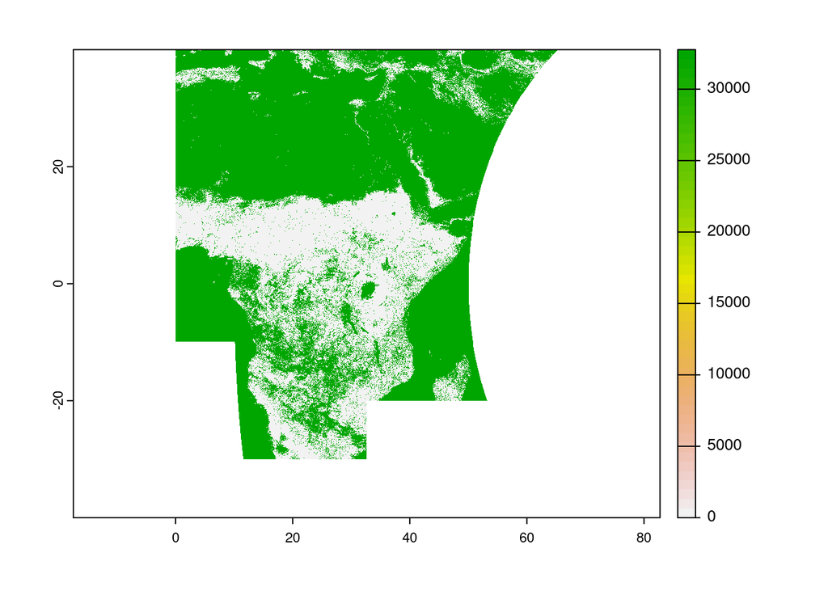

```r
modis <- rast(modis_path)
plot(modis)
```

**Step 2:** now that we have read the raster, we can set the non-vegetated grid-cells (and other unclassiﬁed grid-cells) to NA values. Remember that the non-vegetated grid-cells were represented by values equal or higher than 32761.

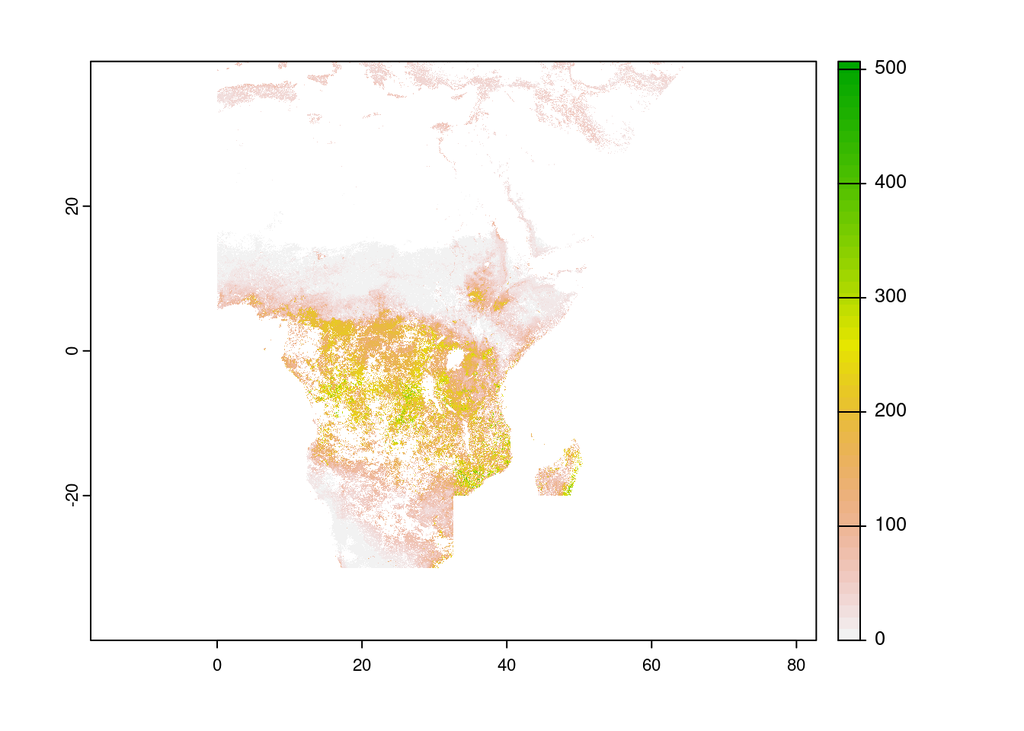

```r
modis[modis >= 32761] <- NA
plot(modis)
```

Why are the values so high? Because a scaling factor needs to be applied to the raw data to obtain the Ea values (see Table 1). Step 3: a scaling factor of 0.1 needs to be applied to the the ET_500m dataset.

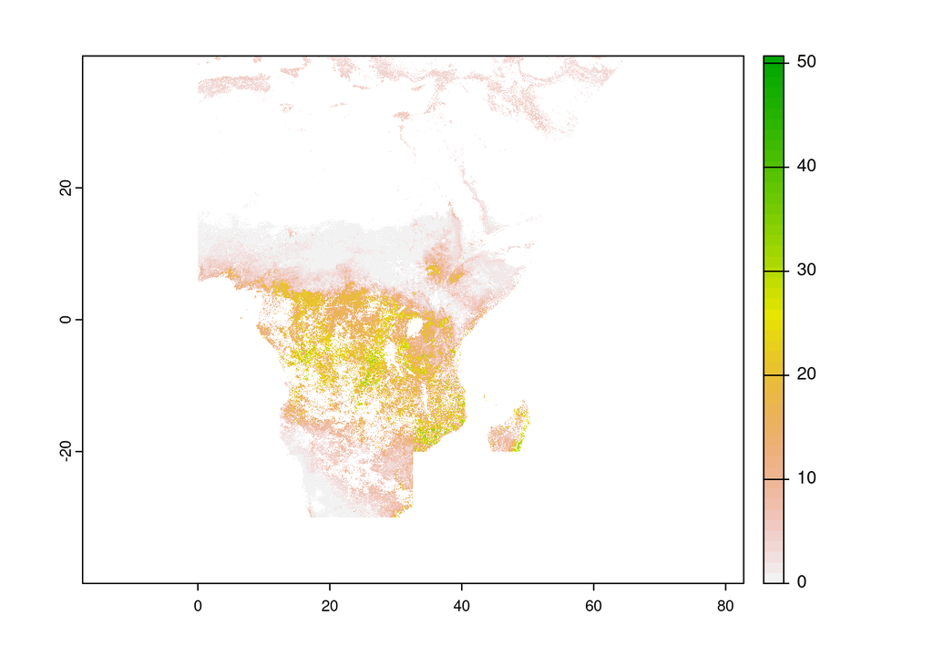

```r
modis <- modis * 0.1
plot(modis)
```

Always consider the order in which you perform operations to a matrix. If we had applied the scaling factor ﬁrst and then looked for cells with a value greater or equal to 32761, we would not have assigned the relevant cells values of NA.

**Step 4:** to export the pre-processed raster, we can use the writeRaster function.

```r
output <- "C:/Users/obaezvil/Data/Exercise_1/Results"
writeRaster(modis, file.path(output, "MODIS_processed_2018_361.tif"),
overwrite = TRUE)
```

## Aggregate SSEBop

The operational Simplified Surface Energy Balance (SSEBop) product (Senay et al. 2013) combines ET fractions generated from MODIS thermal imagery with reference evaporation using a thermal index approach to generate 10-day Ea estimates in milimeters. This product uses pre-defined, seasonally dynamic boundary conditions that are unique to each grid-cell for the cold/wet and hot/dry reference points. In SSEBop, eachmonth is divided into three time steps: $i)$ the first 10 days; $ii)$ the second 10 days; and $iii)$ the remaining days from the 21st to the end of the month.

### Objective of the task

The student should process the 10-day SSEBop to obtain monthly Ea values cropped to the extent of Rwanda for 2009–2011. The derived monthly rasters must be saved in a new folder (with information about the year and month in the file name). For this exercise, 10-day SSEBop raster files are provided (from 2008–2013). Figure 1 shows the first 16 raster files of the 10-day SSEBop data, while Figure 2 plots the shapefile where Rwanda must be subsetted.

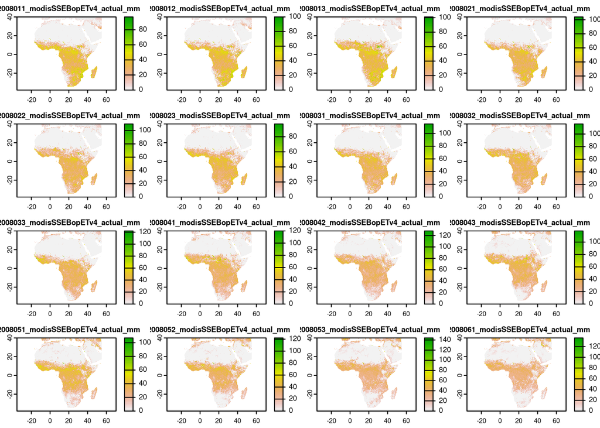

Figure 1: First 16 SSEBop raster files provided

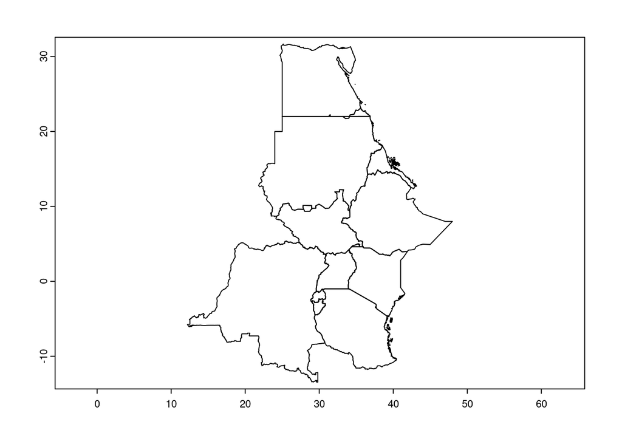

Figure 2: Shapefile of the Nile Basin countries

### Solution

**Step 1:** ﬁrst, let’s load the packages that we will use.

```r
library(terra)
```

**Step 2:** we have to store the paths that we will use: $i)$ the one of the SSEBop ﬁles; $ii)$ the one of the shapeﬁle; and $iii)$ the path where the output ﬁles will be stored.

```r
ssebop     <- "C:/Users/Data/1BSU_2/SSEBop"
shape_path <- "C:/Users/Data/1BSU_2/Countries/Nile_Basin_Countries_GAUL2014_2.shp"
output     <- "C:/Users/Data/Results/SSEBop"
```

**Step 3:** list the ﬁles in the ssebop folder.

```r
files <- list.files(ssebop, full.names = TRUE)
head(files)
```

```
## [1] "../Data/Exercise_2/Part_2/SSEBop/d2008011_modisSSEBopETv4_actual_mm.tif"
## [2] "../Data/Exercise_2/Part_2/SSEBop/d2008012_modisSSEBopETv4_actual_mm.tif"
## [3] "../Data/Exercise_2/Part_2/SSEBop/d2008013_modisSSEBopETv4_actual_mm.tif"
## [4] "../Data/Exercise_2/Part_2/SSEBop/d2008021_modisSSEBopETv4_actual_mm.tif"
## [5] "../Data/Exercise_2/Part_2/SSEBop/d2008022_modisSSEBopETv4_actual_mm.tif"
## [6] "../Data/Exercise_2/Part_2/SSEBop/d2008023_modisSSEBopETv4_actual_mm.tif"
```

**Step 4:** In this step, the function *grep(“2009”, basename(ﬁles))* will return the positions of the 36 ﬁles for 2009 within the list of ﬁles. That means that *min(grep(“2009”, basename(ﬁles)))* will return the position of the ﬁrst of the ﬁles from 2009 (in this case it will be position 37, because positions 1 to 36 are the ﬁles for 2008. Similarly, *max(grep(“2011”, basename(ﬁles)))* will return the position for the last ﬁle in 2011. That means *ﬁles[start:end]* will then return the subset of the ﬁles that are from positions 37 to 144.

```r
# we create a vector of positions 'start:end' for all files
# that contain 2009, 2010, and 2011
start <- min(grep("200901", basename(files)))
end   <- max(grep("201112", basename(files)))
files <- files[start:end]
head(files)
```

```
## [1] "../Data/Exercise_2/Part_2/SSEBop/d2009011_modisSSEBopETv4_actual_mm.tif"
## [2] "../Data/Exercise_2/Part_2/SSEBop/d2009012_modisSSEBopETv4_actual_mm.tif"
## [3] "../Data/Exercise_2/Part_2/SSEBop/d2009013_modisSSEBopETv4_actual_mm.tif"
## [4] "../Data/Exercise_2/Part_2/SSEBop/d2009021_modisSSEBopETv4_actual_mm.tif"
## [5] "../Data/Exercise_2/Part_2/SSEBop/d2009022_modisSSEBopETv4_actual_mm.tif"
## [6] "../Data/Exercise_2/Part_2/SSEBop/d2009023_modisSSEBopETv4_actual_mm.tif"
```

```r
tail(files)
```

```
## [1] "../Data/Exercise_2/Part_2/SSEBop/d2011111_modisSSEBopETv4_actual_mm.tif"
## [2] "../Data/Exercise_2/Part_2/SSEBop/d2011112_modisSSEBopETv4_actual_mm.tif"
## [3] "../Data/Exercise_2/Part_2/SSEBop/d2011113_modisSSEBopETv4_actual_mm.tif"
## [4] "../Data/Exercise_2/Part_2/SSEBop/d2011121_modisSSEBopETv4_actual_mm.tif"
## [5] "../Data/Exercise_2/Part_2/SSEBop/d2011122_modisSSEBopETv4_actual_mm.tif"
## [6] "../Data/Exercise_2/Part_2/SSEBop/d2011123_modisSSEBopETv4_actual_mm.tif"
```

**Step 5:** to read the shapefile we have to use the *vect* function from the **terra** package.

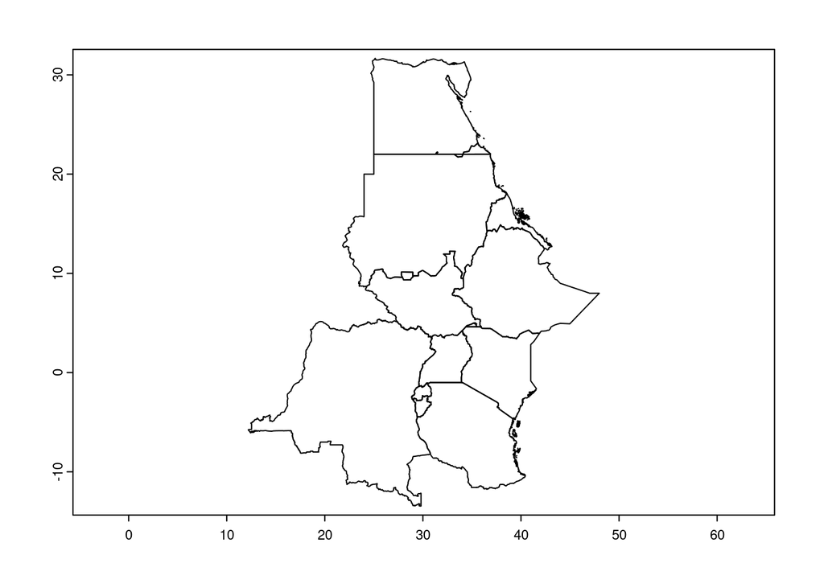

```r
nile_countries <- vect(shape_path)
plot(nile_countries, axes = TRUE)
```

**Step 6:** to subset Rwanda from the *nile.countries* shapeﬁle, we ﬁrst print the attribute table to see which element/position it corresponds to.

```r
values(nile_countries)
```

```
##                   STATUS DISP_AREA ADM0_CODE                        ADM0_NAME
## 1           Member State        NO       205                           Rwanda
## 2           Member State        NO       133                            Kenya
## 3           Member State        NO        74                      South Sudan
## 4           Member State        NO       257      United Republic of Tanzania
## 5           Member State        NO       253                           Uganda
## 6  Sovereignty unsettled       YES     61013                   Ilemi triangle
## 7           Member State        NO        79                         Ethiopia
## 8           Member State        NO        77                          Eritrea
## 9           Member State        NO        43                          Burundi
## 10          Member State        NO        68 Democratic Republic of the Congo
## 11 Sovereignty unsettled       YES     40760                 Hala'ib triangle
## 12 Sovereignty unsettled       YES     40762                  Ma'tan al-Sarra
## 13          Member State        NO         6                            Sudan
## 14          Member State        NO     40765                            Egypt
```

[output cut: 17 more lines]

**Step 7:** the information for Rwanda is located in the ﬁrst row of the table; therefore to subset it, we have to extract the information from the ﬁrst row.

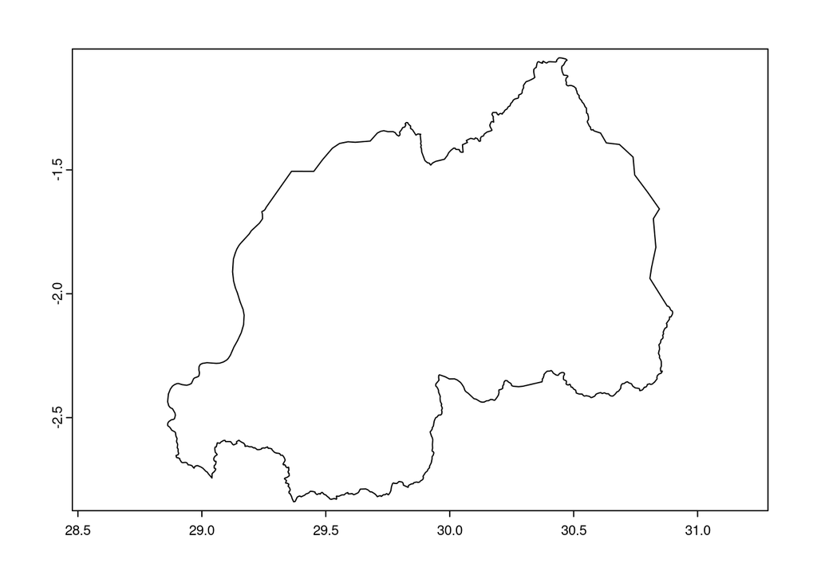

```r
rwanda <- nile_countries[1,]
plot(rwanda, axes = TRUE)
```

**Step 8:** let’s retrieve the years and months of each ﬁle from the ﬁle names.

```r
# Remember that the 2 and 8 represent the position of the first
#  and last characters where the dates are stored

# Characters 6 and 7 refer to the month and character 8 refers to
#  which of the three 10-day periods in the month is considered.

dates <- substr(basename(files), 2, 7)
head(dates)
```

```
## [1] "200901" "200901" "200901" "200902" "200902" "200902"
```

**NOTE:** The function unique returns the values that are included in an object without repetition (i.e., unique values).

**Step 9:** SSEBop product provides three raster ﬁles per month; therefore, we will have three identical dates for each month (one per each 10-day raster). Let’s obtain the unique values in the dates object; these represent every month over which we have data available.

```r
uniq_dates <- unique(dates)
head(uniq_dates)
```

```
## [1] "200901" "200902" "200903" "200904" "200905" "200906"
```

**Step 10:** now we have to create an iterative process that:

1. Loops through all of the months to be analysed.
2. Selects the ﬁles that correspond to the month.
3. Sums the raster ﬁles corresponding to that month.
4. Crops the raster ﬁles to the extent of Rwanda.
5. Exports the resulting monthly raster (with a name that identiﬁes the year and month) to the output folder.

```r
# i will take values from 1 to length(uniq_dates)
# which represent the total number of months in the data
for(i in 1:length(uniq_dates)){

# in the object 'pos' we will store the positions of the
# dates corresponding to the ith element in the uniq_dates object
# e.g., when i == 1, uniq_dates[i] == 200801, and pos == c(1, 2, 3)
pos <- which(dates %in% uniq.dates[i])

# now we will extract these rasters from all the files
monthly <- files[pos]
monthly <- rast(monthly)

# we use the 'crop' function to get the data only for the extent of Rwanda
monthly <- crop(monthly, rwanda, snap = "out")

# we have a stack of three rasters in the 'monthly' object
# now we can proceed to add them
monthly <- sum(monthly)

# finally, we can export the monthly raster
# for this we will create the name that each month must have
name <- paste0("SSEBop_monthly_", uniq.dates[i], ".tif")
writeRaster(monthly, file.path(output, name), overwrite = TRUE)

} # end for
```

## Time Series Analysis

We provide a time series for daily observed streamﬂow for a catchment in Chile (presented in m 3 /s). The data are provided as a zoo object.

1. Convert the times series to a monthly streamﬂow and plot the result.
2. Calculate the mean streamﬂow for each season: DJF (December-January-February); MAM (March-April-May); JJA (June-July-August); and SON (September-October-November). To do this, please refer to the “extract” function in the documentation of the [hydroTSM](https://cran.r-project.org/web/packages/hydroTSM/hydroTSM.pdf) package

### Solution

First we have to load the **hydroTSM** package.

```r
library(hydroTSM)
```

Let’s set the ﬁle path.

```r
q_path <- "C:/Users/Data/Exercise_2/Part_3/Q_observed.zoo"
```

Then, we have to load the ﬁle as a zoo object (it is also possible to read the ﬁle with *read.table* and then convert it to a zoo object).

```r
q_daily <- read.zoo(q_path, header = FALSE)
```

**Part A**

Let’s visualise the data stored in the *q_daily* object.

```r
summary(q_daily)
```

```
##      Index               q_daily
##  Min.   :1990-01-01   Min.   : 0.0202
##  1st Qu.:1997-04-01   1st Qu.: 1.1549
##  Median :2004-07-01   Median : 2.3977
##  Mean   :2004-07-01   Mean   : 3.9221
##  3rd Qu.:2011-10-01   3rd Qu.: 5.2663
##  Max.   :2018-12-31   Max.   :49.6193
##                       NA's   :592
```

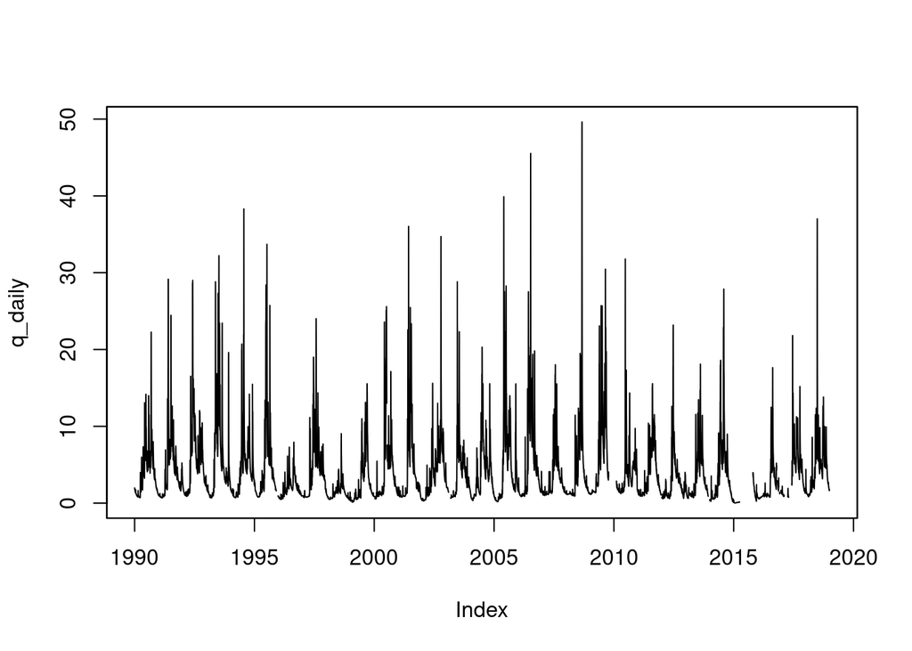

```r
plot(q_daily)
```

Now, we can convert the daily time series into a monthly time series. Here, we provide the *mean* function to the argument *FUN* as we want to obtain the monthly streamﬂow in m$³$/s.

```r
q_monthly <- daily2monthly(q_daily, FUN = mean, na.rm = TRUE)
summary(q_monthly)
```

```
##      Index              q_monthly
##  Min.   :1990-01-01   Min.   : 0.06076
##  1st Qu.:1997-03-24   1st Qu.: 1.19137
##  Median :2004-06-16   Median : 2.48958
##  Mean   :2004-06-16   Mean   : 3.86081
##  3rd Qu.:2011-09-08   3rd Qu.: 5.65717
##  Max.   :2018-12-01   Max.   :15.44473
##                       NA's   :11
```

We can plot the resulting zoo object to visualise the time series.

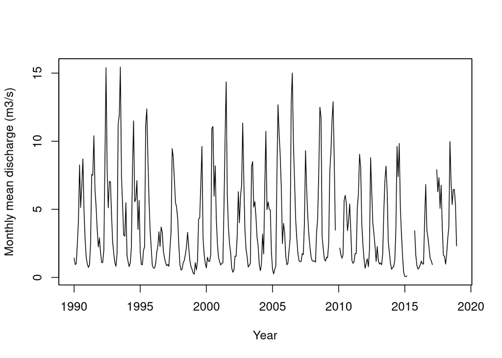

```r
plot(q_monthly, xlab = "Year", ylab = "Monthly mean discharge (m3/s)")
```

**Part B**

Let’s extract entries according to seasons.

```r
q_djf <- hydroTSM::extract(q_daily, trgt = "DJF")
q_mam <- hydroTSM::extract(q_daily, trgt = "MAM")
q_jja <- hydroTSM::extract(q_daily, trgt = "JJA")
q_son <- hydroTSM::extract(q_daily, trgt = "SON")
```

We can plot the object *q_djf* to visualise the results.

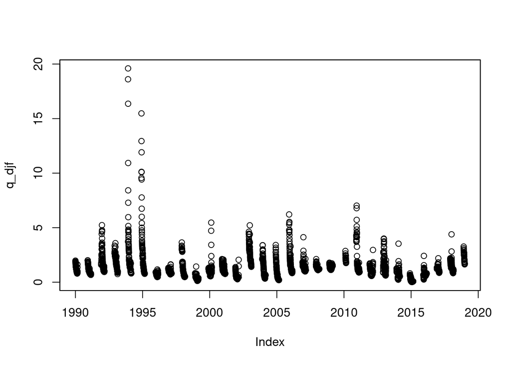

```r
plot(q_djf, type = "p")
```

Finally, we calculate the mean seasonal streamﬂow.

```r
mean_djf <- mean(q_djf, na.rm = TRUE)
mean_mam <- mean(q_mam, na.rm = TRUE)
mean_jja <- mean(q_jja, na.rm = TRUE)
mean_son <- mean(q_son, na.rm = TRUE)
```

Finally, we can print the results of the previous step.

```r
print(mean_djf)
```

```
## [1] 1.366668
```

```r
print(mean_mam)
```

```
## [1] 2.043858
```

```r
print(mean_jja)
```

```
## [1] 7.716251
```

```r
print(mean_son)
```

```
## [1] 4.379506
```

## References

- Mu, Qiaozhen, Faith Ann Heinsch, Maosheng Zhao, and Steven W Running. 2007. “Development of a Global Evapotranspiration Algorithm Based on Modis and Global Meteorology Data.” Remote Sensing of Environment 111 (4). Elsevier: 519–36.
- Mu, Qiaozhen, M Zhao, and SW Running. 2011. “Improvements and Evaluations of the Modis Global Evapotranspiration Algorithm.” Remote Sensing of Environment 115 (8): 1781–1800.
- Running, Steven W, Qiaozhen Mu, Maosheng Zhao, and Alvaro Moreno. 2017. “MODIS Global Terrestrial Evapotranspiration (et) Product (Nasa Mod16a2/A3) Nasa Earth Observing System Modis Land Algorithm.” NASA: Washington, DC, USA.
- Senay, Gabriel B, Stefanie Bohms, Ramesh K Singh, Prasanna H Gowda, Naga M Velpuri, Henok Alemu, and James P Verdin. 2013. “Operational Evapotranspiration Mapping Using Remote Sensing and Weather Datasets: A New Parameterization for the Sseb Approach.” JAWRA Journal of the American Water Resources Association 49 (3). Wiley Online Library: 577–91.